# Who Are The Best Professional League of Legends Players?

[figure not shown]

## Introduction

League of Legends (LoL) is a MOBA (Multiplayer Online Battle Arena) game developed by Riot Games. Released in 2009, LoL has rapidly grown in popularity, having become one of the most played multiplayer online games and most played electronic sport (e-sport) in the world. As of 2021 it boasts a global revenue of $15 billion USD, professional franchises and partnerships worth hundreds of millions of dollars, and 115 million active monthly users with over 150 million registered users. The premise of the game is relatively simple: Two teams of five players battle in player versus player combat, each team occupying and defending their half of the map. Each of the ten players controls a unique character with distinct abilities and differing styles of play. During a match, champions become more powerful by collecting experience points, earning gold, and purchasing items to defeat the opposing team. In the game a team wins by pushing through to the enemy base and destroying their "Nexus", a large structure located within. More information can be found [here](https://na.leagueoflegends.com/en-us/how-to-play/).

## Motivation

In my tutorial, I am interested in shedding some light on who are considered the best professional League of Legends players, as well as finding out what factors make a player "good". As we have learned from the Moneyball story on the strength of utilizing data science in producing a strong baseball team, I believe this project can similarly represent good data science practices in order to create a similarly strong League of Legends e-sport team. While it may be relatively straightforward to conclude who are the best League of Legends players of each year by identifying the winners of each year's World Championship, perhaps there are other characteristics between players that could indicate factors which help make a team more likely to win. Data science practices help us in this regard by giving us tools to help identify player characterstics, clarity on how those characteristics might relate to player performance, and determine whether any particular element should be focused on when identifying and drafting professional players. For readers that are unfamiliar with the game, I hope this analysis will act as a gentle introduction into League of Legends and make them interested in trying out the game, as well as follow its professional scene as the game continues to take the world by storm. For experienced players and growing franchises, I hope to provide some insight on intriguing statistic correlations between the best League of Legends players, as well as help with drafting promising individual talents into fantasy teams or professional teams.

## Getting Started

We begin with using Python3 and a few imported libraries listed below which you can learn more about here: [pandas](https://pandas.pydata.org/pandas-docs/stable/user_guide/index.html), [numpy](https://numpy.org/doc/stable/user/), [matplotlib](https://matplotlib.org/stable/tutorials/index.html), [seaborn](https://seaborn.pydata.org/tutorial.html), [sklearn](https://scikit-learn.org/stable/user_guide.html)

```python
import pandas as pd
import numpy as np
import matplotlib.pyplot as plt
import seaborn as sns
import json
import requests
import warnings
from sklearn.linear_model import LinearRegression
```

## Data Collection and Preprocessing

With the conclusion of the 2020 League of Legends World Championship, we will be pulling the player statistics from every player that participated in the League of Legends World Championships from 2014-2020 from this [website](https://www.rotowire.com/esports/stats-lol.php?league=297&series=&tourn=) that hosts a plethora of player statistics for recreational fantasy team building.

```python
# Obtaining 2014 League of Legends World Championship Data
r = requests.get("https://www.rotowire.com/esports/tables/stats-lol.php?type=total&league=297&series=4")
array = json.loads(r.content)
df2014 = pd.DataFrame()
for i in array:
    df2014 = df2014.append(i, ignore_index=True)
df2014['year'] = 2014

# Obtaining 2015 League of Legends World Championship Data
r = requests.get("https://www.rotowire.com/esports/tables/stats-lol.php?type=total&league=297&series=30")
array = json.loads(r.content)
df2015 = pd.DataFrame()
for i in array:
    df2015 = df2015.append(i, ignore_index=True)
df2015['year'] = 2015

# Obtaining 2016 League of Legends World Championship Data
r = requests.get("https://www.rotowire.com/esports/tables/stats-lol.php?type=total&league=297&series=669")
array = json.loads(r.content)
df2016 = pd.DataFrame()
for i in array:
    df2016 = df2016.append(i, ignore_index=True)
df2016['year'] = 2016

# Obtaining 2017 League of Legends World Championship Data
r = requests.get("https://www.rotowire.com/esports/tables/stats-lol.php?type=total&league=297&series=1308")
array = json.loads(r.content)
df2017 = pd.DataFrame()
for i in array:
    df2017 = df2017.append(i, ignore_index=True)
df2017['year'] = 2017

# Obtaining 2018 League of Legends World Championship Data
r = requests.get("https://www.rotowire.com/esports/tables/stats-lol.php?type=total&league=297&series=1605")
array = json.loads(r.content)
df2018 = pd.DataFrame()
for i in array:
    df2018 = df2018.append(i, ignore_index=True)
df2018['year'] = 2018

# Obtaining 2019 League of Legends World Championship Data
r = requests.get("https://www.rotowire.com/esports/tables/stats-lol.php?type=total&league=297&series=1839")
array = json.loads(r.content)
df2019 = pd.DataFrame()
for i in array:
    df2019 = df2019.append(i, ignore_index=True)
df2019['year'] = 2019

# Obtaining 2020 League of Legends World Championship Data
r = requests.get("https://www.rotowire.com/esports/tables/stats-lol.php?type=total&league=297&series=2987")
array = json.loads(r.content)
df2020 = pd.DataFrame()
for i in array:
    df2020 = df2020.append(i, ignore_index=True)
df2020['year'] = 2020
```

## Reading the Data

```python
pd.set_option('display.max_columns', None)
df2014.head()
```

|  | ID | assists | cs | csm | deathperc | deaths | dpm | fb | firstname | gamertag | games | goldperc | kda | kills | killshare | kp | lastname | losses | matchLength | matches | pandaTeam | player | playerDam | playerGold | role | team | teamDam | teamDeaths | teamGold | … |
| --- | --- | --- | --- | --- | --- | --- | --- | --- | --- | --- | --- | --- | --- | --- | --- | --- | --- | --- | --- | --- | --- | --- | --- | --- | --- | --- | --- | --- | --- | --- |
| 0 | 570 | 105 | 6217 | 8.8 | 16.4 | 49 | 591.6 | 4 | Jian | Uzi | 20 | 25.1 | 4.4 | 112 | 36.0 | 69.8 | Zi-Hao | 8 | 707.299996 | 9 | Royal Club | Jian Zi-Hao | 418406 | 294411 | ADC |  | 1261411 | 299 | 1174035 | … |
| 1 | 472 | 141 | 4172 | 8.4 | 18.7 | 25 | 563.8 | 1 | Heo | PawN | 17 | 21.9 | 9.9 | 106 | 27.6 | 64.3 | Won-seok | 2 | 496.616661 | 9 | Samsung White | Heo Won-seok | 280000 | 210602 | MID |  | 1003895 | 134 | 961715 | … |
| 2 | 478 | 124 | 3700 | 7.5 | 21.6 | 29 | 580.6 | 2 | Gu | Imp | 17 | 20.8 | 7.9 | 105 | 27.3 | 59.6 | Seung-bin | 2 | 496.616661 | 9 | Samsung White | Gu Seung-bin | 288356 | 199788 | ADC |  | 1003895 | 134 | 961715 | … |
| 3 | 464 | 188 | 1841 | 3.7 | 23.9 | 32 | 358.8 | 3 | Choi | DanDy | 17 | 18.5 | 8.5 | 84 | 21.9 | 70.8 | In-kyu | 2 | 496.616661 | 9 | Samsung White | Choi In-kyu | 178185 | 178080 | JNG |  | 1003895 | 134 | 961715 | … |
| 4 | 473 | 66 | 3342 | 7.5 | 17.4 | 35 | 674.9 | 2 | Kim | Deft | 13 | 23.5 | 4.3 | 83 | 38.4 | 69.0 | Hyuk-kyu | 5 | 444.933329 | 8 | Samsung Blue | Kim Hyuk-kyu | 300301 | 176061 | ADC |  | 823722 | 201 | 749593 | … |

In the above example 2014 World Championship dataset there are 37 columns. We have:

- ID (Unique player ID#)
- Assists
- CS (Creep score)
- CSM (Creep score per minute)
- Death Percentage (The percentage of deaths a player had in accordance with their team)
- Deaths
- DPM (Damage per minute to other players)
- [FB](https://leagueoflegends.fandom.com/wiki/Kill#Bounties) (Number of first kill of the game earned by player)
- First Name
- Gamertag (Unique player username)
- Games (Number of games played)
- Gold Percentage (The percentage of gold that a player gained for their team)
- [KDA](https://leagueoflegends.fandom.com/wiki/Kill_to_Death_Ratio) (Kill/Death/Assist Ratio)
- Kills
- Kill Share Percentage (The number of the players kills divided by the number of team kills)
- Kill Participation Percentage (The number of kills and assists divided by the number of team kills)
- Last Name
- Losses
- Matches (Number of matches played)
- Panda Team (Team Name)
- Player (Player Full Name)
- Player Damage (Total damage dealt to other players)
- Player Gold (Total gold gained by the player)
- Role (Position played by the player: [Top, Mid, Jungle, Support, ADC](https://leagueoflegends.fandom.com/wiki/Lanes))
- Team (Secondary column for team name)
- Team Damage (Total damage dealt to other players by the team)
- Team Gold (Total gold earned by the team)
- Team ID (Tertiary column for team name)
- Team Kills (Total number of kills earned by the team)
- Wards Cleared (Number of [wards](https://leagueoflegends.fandom.com/wiki/Ward) removed by player)
- Wards Placed (Number of wards placed by player)
- WCPM (Wards cleared per minute)
- Wins
- WPM (Wards placed per minute)
- Year

The titles of each column here should also be self-explanatory. If you'd like to learn more about a column within the context of the game, important topics have links to additional information.

## Data Tidying

As we can see above, there are many catagories above that are not needed as well as duplicate columns and rows containing essentially the same information, along with additional missing information that would be helpful later on during data analysis. For the sake of brevity we will be removing all columns involving player names and IDs, and will only be refering to players by their gamer tag from here on out.

Afterwards, we will be re-naming the Panda Team column to the team name column as the intial title name is confusing, as well as dropping the columns of 'team', 'teamID', 'matchLength', 'playerDam', 'playerGold', 'teamDam', 'teamDeaths', 'teamGold','teamKills' as they do not provide any useful or insightful information on the respective individuals in question. We will also be rearranging and renaming the columns of the dataframe for clarity. These changes will be applied to all dataframes along with an additional column being added identifying the winners of the world championship for each year which was found externally from [here](https://en.wikipedia.org/wiki/League_of_Legends_World_Championship), which will be useful to us later during our data analysis.

```python
# Removing First Name, Last Name, Matches, Player Name, Player ID, Team, Team ID
# Match Length, Player Damage, Player Gold, Team Damage, Team Deaths,
# Team Gold, and Team Kills columns from all dataframes

df2014.drop(['firstname', 'lastname', 'matches', 'player', 'ID', 'team', 'teamID',
             'matchLength', 'playerDam', 'playerGold', 'teamDam',
             'teamDeaths', 'teamGold','teamKills'], axis=1, inplace=True)

df2015.drop(['firstname', 'lastname', 'matches', 'player', 'ID', 'team', 'teamID',
             'matchLength', 'playerDam', 'playerGold', 'teamDam',
             'teamDeaths', 'teamGold','teamKills'], axis=1, inplace=True)

df2016.drop(['firstname', 'lastname', 'matches', 'player', 'ID', 'team', 'teamID',
             'matchLength', 'playerDam', 'playerGold', 'teamDam',
             'teamDeaths', 'teamGold','teamKills'], axis=1, inplace=True)

df2017.drop(['firstname', 'lastname', 'matches', 'player', 'ID', 'team', 'teamID',
             'matchLength', 'playerDam', 'playerGold', 'teamDam',
             'teamDeaths', 'teamGold','teamKills'], axis=1, inplace=True)

df2018.drop(['firstname', 'lastname', 'matches', 'player', 'ID', 'team', 'teamID',
             'matchLength', 'playerDam', 'playerGold', 'teamDam',
             'teamDeaths', 'teamGold','teamKills'], axis=1, inplace=True)

df2019.drop(['firstname', 'lastname', 'matches', 'player', 'ID', 'team', 'teamID',
             'matchLength', 'playerDam', 'playerGold', 'teamDam',
             'teamDeaths', 'teamGold','teamKills'], axis=1, inplace=True)

df2020.drop(['firstname', 'lastname', 'matches', 'player', 'ID', 'team', 'teamID',
             'matchLength', 'playerDam', 'playerGold', 'teamDam',
             'teamDeaths', 'teamGold','teamKills'], axis=1, inplace=True)

# Reindexing columns in all dataframes for clairty
rearrangedColumns = ['year','gamertag','pandaTeam','role','games','wins','losses','assists',
                    'kda','kp','killshare','cs','csm','goldperc','dpm','fb','deathperc','wpm','wcpm']

df2014 = df2014.reindex(columns=rearrangedColumns)
df2015 = df2015.reindex(columns=rearrangedColumns)
df2016 = df2016.reindex(columns=rearrangedColumns)
df2017 = df2017.reindex(columns=rearrangedColumns)
df2018 = df2018.reindex(columns=rearrangedColumns)
df2019 = df2019.reindex(columns=rearrangedColumns)
df2020 = df2020.reindex(columns=rearrangedColumns)

# Renaming pandaTeam column in all dataframes for clarity
df2014 = df2014.rename(columns={'pandaTeam':'team'})
df2015 = df2015.rename(columns={'pandaTeam':'team'})
df2016 = df2016.rename(columns={'pandaTeam':'team'})
df2017 = df2017.rename(columns={'pandaTeam':'team'})
df2018 = df2018.rename(columns={'pandaTeam':'team'})
df2019 = df2019.rename(columns={'pandaTeam':'team'})
df2020 = df2020.rename(columns={'pandaTeam':'team'})
```

```python
# Create a new column initalized to False indicating if the player won the World Championship for the respective year
df2014['worldchamp'] = False
df2015['worldchamp'] = False
df2016['worldchamp'] = False
df2017['worldchamp'] = False
df2018['worldchamp'] = False
df2019['worldchamp'] = False
df2020['worldchamp'] = False

# Iterate over each dataframe and assign the respective World Champion of that year
for index, row in df2014.iterrows():
    if row['team'] == 'Samsung White':
       df2014.at[index,'worldchamp'] = True

for index, row in df2015.iterrows():
    if row['team'] == 'SK telecom T1':
       df2015.at[index,'worldchamp'] = True

for index, row in df2016.iterrows():
    if row['team'] == 'SK telecom T1':
       df2016.at[index,'worldchamp'] = True

for index, row in df2017.iterrows():
    if row['team'] == 'Samsung Galaxy':
       df2017.at[index,'worldchamp'] = True

for index, row in df2018.iterrows():
    if row['team'] == 'Invictus Gaming':
       df2018.at[index,'worldchamp'] = True

for index, row in df2019.iterrows():
    if row['team'] == 'FunPlus Phoenix':
       df2019.at[index,'worldchamp'] = True

for index, row in df2020.iterrows():
    if row['team'] == 'DAMWON Gaming':
       df2020.at[index,'worldchamp'] = True
```

```python
df2014.head()
```

|  | year | gamertag | team | role | games | wins | losses | assists | kda | kp | killshare | cs | csm | goldperc | dpm | fb | deathperc | wpm | wcpm | worldchamp |
| --- | --- | --- | --- | --- | --- | --- | --- | --- | --- | --- | --- | --- | --- | --- | --- | --- | --- | --- | --- | --- |
| 0 | 2014 | Uzi | Royal Club | ADC | 20 | 12 | 8 | 105 | 4.4 | 69.8 | 36.0 | 6217 | 8.8 | 25.1 | 591.6 | 4 | 16.4 | 0.17 | 0.19 | False |
| 1 | 2014 | PawN | Samsung White | MID | 17 | 15 | 2 | 141 | 9.9 | 64.3 | 27.6 | 4172 | 8.4 | 21.9 | 563.8 | 1 | 18.7 | 0.37 | 0.17 | True |
| 2 | 2014 | Imp | Samsung White | ADC | 17 | 15 | 2 | 124 | 7.9 | 59.6 | 27.3 | 3700 | 7.5 | 20.8 | 580.6 | 2 | 21.6 | 0.25 | 0.13 | True |
| 3 | 2014 | DanDy | Samsung White | JNG | 17 | 15 | 2 | 188 | 8.5 | 70.8 | 21.9 | 1841 | 3.7 | 18.5 | 358.8 | 3 | 23.9 | 0.55 | 0.19 | True |
| 4 | 2014 | Deft | Samsung Blue | ADC | 13 | 8 | 5 | 66 | 4.3 | 69.0 | 38.4 | 3342 | 7.5 | 23.5 | 674.9 | 2 | 17.4 | 0.27 | 0.17 | False |

### League of Legends Champions

Ezreal, Lee Sin, Lux, Teemo, Leona pictured left to right

[figure not shown]

## Data Preparation

Now that the clarity of our dataframes have been improved, we will create an additional dataframe concatenating all the player statistics from the previous dataframes of the years 2014 to 2020 so that we can better analyze potential correlations between specific statistics across all years of the World Championships later on in our exploratory data anaylsis section.

```python
# Collecting all the dataframes and storing them inside an array to be concatenated
frames = [df2014,df2015,df2016,df2017,df2018,df2019,df2020]
dfTotal = pd.concat(frames)
```

```python
dfTotal
```

|  | year | gamertag | team | role | games | wins | losses | assists | kda | kp | killshare | cs | csm | goldperc | dpm | fb | deathperc | wpm | wcpm | worldchamp |
| --- | --- | --- | --- | --- | --- | --- | --- | --- | --- | --- | --- | --- | --- | --- | --- | --- | --- | --- | --- | --- |
| 0 | 2014 | Uzi | Royal Club | ADC | 20 | 12 | 8 | 105 | 4.4 | 69.8 | 36.0 | 6217 | 8.8 | 25.1 | 591.6 | 4 | 16.4 | 0.17 | 0.19 | False |
| 1 | 2014 | PawN | Samsung White | MID | 17 | 15 | 2 | 141 | 9.9 | 64.3 | 27.6 | 4172 | 8.4 | 21.9 | 563.8 | 1 | 18.7 | 0.37 | 0.17 | True |
| 2 | 2014 | Imp | Samsung White | ADC | 17 | 15 | 2 | 124 | 7.9 | 59.6 | 27.3 | 3700 | 7.5 | 20.8 | 580.6 | 2 | 21.6 | 0.25 | 0.13 | True |
| 3 | 2014 | DanDy | Samsung White | JNG | 17 | 15 | 2 | 188 | 8.5 | 70.8 | 21.9 | 1841 | 3.7 | 18.5 | 358.8 | 3 | 23.9 | 0.55 | 0.19 | True |
| 4 | 2014 | Deft | Samsung Blue | ADC | 13 | 8 | 5 | 66 | 4.3 | 69.0 | 38.4 | 3342 | 7.5 | 23.5 | 674.9 | 2 | 17.4 | 0.27 | 0.17 | False |
| ... | ... | ... | ... | ... | ... | ... | ... | ... | ... | ... | ... | ... | ... | ... | ... | ... | ... | ... | ... | ... |
| 97 | 2020 | Vander | Rogue | SUP | 6 | 1 | 5 | 31 | 1.9 | 69.8 | 11.3 | 219 | 1.2 | 13.5 | 132.9 | 1 | 21.8 | 1.81 | 0.30 | False |
| 98 | 2020 | RedBert | INTZ e-Sports | SUP | 5 | 1 | 4 | 33 | 2.4 | 71.7 | 9.4 | 238 | 1.3 | 13.5 | 152.1 | 0 | 22.5 | 1.85 | 0.42 | False |
| 99 | 2020 | IgNar | FlyQuest | SUP | 6 | 3 | 3 | 39 | 2.9 | 59.7 | 5.6 | 175 | 0.9 | 12.9 | 141.7 | 0 | 18.8 | 1.59 | 0.37 | False |
| 100 | 2020 | Biofrost | Team SoloMid | SUP | 6 | 0 | 6 | 26 | 1.6 | 60.4 | 6.3 | 241 | 1.2 | 12.9 | 116.6 | 0 | 21.2 | 1.77 | 0.52 | False |
| 101 | 2020 | Koala | Machi Esports | SUP | 6 | 1 | 5 | 27 | 1.3 | 53.7 | 3.7 | 293 | 1.5 | 12.8 | 147.2 | 0 | 22.3 | 1.83 | 0.68 | False |

701 rows × 20 columns

Next we will be creating seperate dataframes grouped by position for each year between the years of 2014-2020 so that we can compare players to others playing within the same position in the World Championships.

```python
# Initalizing position dataframes to dataframes of that year
top2014 = df2014
mid2014 = df2014
jng2014 = df2014
adc2014 = df2014
sup2014 = df2014

top2015 = df2015
mid2015 = df2015
jng2015 = df2015
adc2015 = df2015
sup2015 = df2015

top2016 = df2016
mid2016 = df2016
jng2016 = df2016
adc2016 = df2016
sup2016 = df2016

top2017 = df2017
mid2017 = df2017
jng2017 = df2017
adc2017 = df2017
sup2017 = df2017

top2018 = df2018
mid2018 = df2018
jng2018 = df2018
adc2018 = df2018
sup2018 = df2018

top2019 = df2019
mid2019 = df2019
jng2019 = df2019
adc2019 = df2019
sup2019 = df2019

top2020 = df2020
mid2020 = df2020
jng2020 = df2020
adc2020 = df2020
sup2020 = df2020
```

```python
# Iterate through each year of the position dataframes and drop positions that do not match the TOP position
for i, row in top2014.iterrows():
    if row['role'] != 'TOP':
        top2014 = top2014.drop([i])

for i, row in top2015.iterrows():
    if row['role'] != 'TOP':
        top2015 = top2015.drop([i])

for i, row in top2016.iterrows():
    if row['role'] != 'TOP':
        top2016 = top2016.drop([i])

for i, row in top2017.iterrows():
    if row['role'] != 'TOP':
        top2017 = top2017.drop([i])

for i, row in top2018.iterrows():
    if row['role'] != 'TOP':
        top2018 = top2018.drop([i])

for i, row in top2019.iterrows():
    if row['role'] != 'TOP':
        top2019 = top2019.drop([i])

for i, row in top2020.iterrows():
    if row['role'] != 'TOP':
        top2020 = top2020.drop([i])
```

```python
# Iterate through each year of the position dataframes and drop positions that do not match the MID position
for i, row in mid2014.iterrows():
    if row['role'] != 'MID':
        mid2014 = mid2014.drop([i])

for i, row in mid2015.iterrows():
    if row['role'] != 'MID':
        mid2015 = mid2015.drop([i])

for i, row in mid2016.iterrows():
    if row['role'] != 'MID':
        mid2016 = mid2016.drop([i])

for i, row in mid2017.iterrows():
    if row['role'] != 'MID':
        mid2017 = mid2017.drop([i])

for i, row in mid2018.iterrows():
    if row['role'] != 'MID':
        mid2018 = mid2018.drop([i])

for i, row in mid2019.iterrows():
    if row['role'] != 'MID':
        mid2019 = mid2019.drop([i])

for i, row in mid2020.iterrows():
    if row['role'] != 'MID':
        mid2020 = mid2020.drop([i])
```

```python
# Iterate through each year of the position dataframes and drop positions that do not match the JNG position
for i, row in jng2014.iterrows():
    if row['role'] != 'JNG':
        jng2014 = jng2014.drop([i])

for i, row in jng2015.iterrows():
    if row['role'] != 'JNG':
        jng2015 = jng2015.drop([i])

for i, row in jng2016.iterrows():
    if row['role'] != 'JNG':
        jng2016 = jng2016.drop([i])

for i, row in jng2017.iterrows():
    if row['role'] != 'JNG':
        jng2017 = jng2017.drop([i])

for i, row in jng2018.iterrows():
    if row['role'] != 'JNG':
        jng2018 = jng2018.drop([i])

for i, row in jng2019.iterrows():
    if row['role'] != 'JNG':
        jng2019 = jng2019.drop([i])

for i, row in jng2020.iterrows():
    if row['role'] != 'JNG':
        jng2020 = jng2020.drop([i])
```

```python
# Iterate through each year of the position dataframes and drop positions that do not match the ADC position
for i, row in adc2014.iterrows():
    if row['role'] != 'ADC':
        adc2014 = adc2014.drop([i])

for i, row in adc2015.iterrows():
    if row['role'] != 'ADC':
        adc2015 = adc2015.drop([i])

for i, row in adc2016.iterrows():
    if row['role'] != 'ADC':
        adc2016 = adc2016.drop([i])

for i, row in adc2017.iterrows():
    if row['role'] != 'ADC':
        adc2017 = adc2017.drop([i])

for i, row in adc2018.iterrows():
    if row['role'] != 'ADC':
        adc2018 = adc2018.drop([i])

for i, row in adc2019.iterrows():
    if row['role'] != 'ADC':
        adc2019 = adc2019.drop([i])

for i, row in adc2020.iterrows():
    if row['role'] != 'ADC':
        adc2020 = adc2020.drop([i])
```

```python
# Iterate through each year of the position dataframes and drop positions that do not match the SUP position
for i, row in sup2014.iterrows():
    if row['role'] != 'SUP':
        sup2014 = sup2014.drop([i])

for i, row in sup2015.iterrows():
    if row['role'] != 'SUP':
        sup2015 = sup2015.drop([i])

for i, row in sup2016.iterrows():
    if row['role'] != 'SUP':
        sup2016 = sup2016.drop([i])

for i, row in sup2017.iterrows():
    if row['role'] != 'SUP':
        sup2017 = sup2017.drop([i])

for i, row in sup2018.iterrows():
    if row['role'] != 'SUP':
        sup2018 = sup2018.drop([i])

for i, row in sup2019.iterrows():
    if row['role'] != 'SUP':
        sup2019 = sup2019.drop([i])

for i, row in sup2020.iterrows():
    if row['role'] != 'SUP':
        sup2020 = sup2020.drop([i])
```

```python
top2014.head()
```

|  | year | gamertag | team | role | games | wins | losses | assists | kda | kp | killshare | cs | csm | goldperc | dpm | fb | deathperc | wpm | wcpm | worldchamp |
| --- | --- | --- | --- | --- | --- | --- | --- | --- | --- | --- | --- | --- | --- | --- | --- | --- | --- | --- | --- | --- |
| 5 | 2014 | Looper | Samsung White | TOP | 17 | 15 | 2 | 184 | 12.1 | 66.4 | 18.5 | 3463 | 7.0 | 19.8 | 393.7 | 2 | 15.7 | 0.34 | 0.13 | True |
| 14 | 2014 | Koro1 | EDward Gaming | TOP | 12 | 6 | 6 | 83 | 3.4 | 65.1 | 22.6 | 2903 | 6.7 | 21.2 | 397.1 | 0 | 21.9 | 0.27 | 0.12 | False |
| 22 | 2014 | Save | NaJin White Shield | TOP | 10 | 5 | 5 | 40 | 2.1 | 58.1 | 23.9 | 2826 | 7.0 | 21.4 | 410.6 | 0 | 26.2 | 0.39 | 0.21 | False |
| 25 | 2014 | Balls | Cloud9 | TOP | 11 | 5 | 6 | 61 | 2.1 | 59.9 | 16.9 | 2492 | 6.2 | 20.1 | 363.3 | 0 | 22.9 | 0.36 | 0.13 | False |
| 27 | 2014 | Acorn | Samsung Blue | TOP | 13 | 8 | 5 | 108 | 3.3 | 60.2 | 10.2 | 2533 | 5.7 | 19.2 | 344.9 | 1 | 19.9 | 0.37 | 0.13 | False |

```python
mid2015.head()
```

|  | year | gamertag | team | role | games | wins | losses | assists | kda | kp | killshare | cs | csm | goldperc | dpm | fb | deathperc | wpm | wcpm | worldchamp |
| --- | --- | --- | --- | --- | --- | --- | --- | --- | --- | --- | --- | --- | --- | --- | --- | --- | --- | --- | --- | --- |
| 2 | 2015 | KurO | ROX Tigers | MID | 17 | 11 | 6 | 124 | 6.1 | 73.5 | 28.4 | 4814 | 8.1 | 22.7 | 529.4 | 1 | 17.9 | 0.59 | 0.18 | False |
| 6 | 2015 | Faker | SK telecom T1 | MID | 12 | 11 | 1 | 77 | 7.3 | 64.4 | 26.8 | 3337 | 8.3 | 21.9 | 577.6 | 3 | 18.2 | 0.30 | 0.16 | True |
| 9 | 2015 | Maple | Flash Wolves | MID | 10 | 5 | 5 | 63 | 6.6 | 79.4 | 34.8 | 3407 | 8.1 | 23.4 | 624.0 | 3 | 14.4 | 0.38 | 0.22 | False |
| 10 | 2015 | Febiven | Fnatic | MID | 12 | 7 | 5 | 69 | 4.5 | 65.5 | 26.6 | 3999 | 9.6 | 23.2 | 573.4 | 3 | 14.9 | 0.21 | 0.17 | False |
| 17 | 2015 | Nagne | KT Rolster | MID | 10 | 6 | 4 | 56 | 4.5 | 61.8 | 22.9 | 3395 | 8.8 | 22.5 | 383.2 | 1 | 20.0 | 0.61 | 0.10 | False |

```python
jng2016.head()
```

|  | year | gamertag | team | role | games | wins | losses | assists | kda | kp | killshare | cs | csm | goldperc | dpm | fb | deathperc | wpm | wcpm | worldchamp |
| --- | --- | --- | --- | --- | --- | --- | --- | --- | --- | --- | --- | --- | --- | --- | --- | --- | --- | --- | --- | --- |
| 3 | 2016 | Peanut | ROX Tigers | JNG | 16 | 10 | 6 | 98 | 5.8 | 66.8 | 28.1 | 2398 | 3.9 | 19.6 | 326.7 | 7 | 14.9 | 0.78 | 0.42 | False |
| 12 | 2016 | Jankos | H2K | JNG | 13 | 8 | 5 | 86 | 5.0 | 68.9 | 21.9 | 1846 | 3.9 | 19.1 | 294.2 | 2 | 20.8 | 1.05 | 0.60 | False |
| 17 | 2016 | Ambition | Samsung Galaxy | JNG | 17 | 13 | 4 | 113 | 3.7 | 59.1 | 13.4 | 3004 | 4.6 | 19.6 | 344.1 | 5 | 20.7 | 0.82 | 0.50 | False |
| 25 | 2016 | Bengi | SK telecom T1 | JNG | 10 | 8 | 2 | 72 | 5.8 | 64.5 | 17.1 | 1952 | 4.3 | 18.5 | 359.6 | 2 | 20.0 | 0.80 | 0.69 | True |
| 26 | 2016 | Blank | SK telecom T1 | JNG | 10 | 6 | 4 | 68 | 4.9 | 68.1 | 18.8 | 1696 | 4.3 | 19.3 | 285.0 | 2 | 16.4 | 0.90 | 0.54 | True |

```python
adc2017.head()
```

|  | year | gamertag | team | role | games | wins | losses | assists | kda | kp | killshare | cs | csm | goldperc | dpm | fb | deathperc | wpm | wcpm | worldchamp |
| --- | --- | --- | --- | --- | --- | --- | --- | --- | --- | --- | --- | --- | --- | --- | --- | --- | --- | --- | --- | --- |
| 0 | 2017 | Mystic | Team WE | ADC | 22 | 16 | 6 | 98 | 4.1 | 69.5 | 32.1 | 6732 | 9.4 | 23.4 | 764.9 | 3 | 25.0 | 0.37 | 0.37 | False |
| 2 | 2017 | Uzi | Royal Never Give Up | ADC | 15 | 10 | 5 | 43 | 8.5 | 75.3 | 48.1 | 5887 | 10.8 | 25.1 | 769.9 | 2 | 12.8 | 0.40 | 0.39 | False |
| 3 | 2017 | Padden | 1907 Fenerbah&ccedil;e Esports | ADC | 15 | 7 | 8 | 46 | 4.1 | 78.9 | 48.7 | 5574 | 9.7 | 24.1 | 738.9 | 1 | 17.1 | 0.28 | 0.30 | False |
| 5 | 2017 | Rekkles | Fnatic | ADC | 19 | 11 | 8 | 77 | 5.2 | 69.7 | 31.3 | 7544 | 11.0 | 25.0 | 622.7 | 4 | 16.6 | 0.30 | 0.39 | False |
| 7 | 2017 | Sneaky | Cloud9 | ADC | 18 | 12 | 6 | 77 | 5.2 | 68.7 | 29.8 | 5578 | 9.4 | 22.9 | 781.4 | 0 | 18.1 | 0.37 | 0.39 | False |

```python
sup2018.head()
```

|  | year | gamertag | team | role | games | wins | losses | assists | kda | kp | killshare | cs | csm | goldperc | dpm | fb | deathperc | wpm | wcpm | worldchamp |
| --- | --- | --- | --- | --- | --- | --- | --- | --- | --- | --- | --- | --- | --- | --- | --- | --- | --- | --- | --- | --- |
| 44 | 2018 | Koala | G-Rex | SUP | 14 | 7 | 7 | 101 | 2.5 | 68.9 | 11.9 | 478 | 1.1 | 13.9 | 199.5 | 2 | 25.7 | 1.41 | 0.30 | False |
| 47 | 2018 | Baolan | Invictus Gaming | SUP | 18 | 14 | 4 | 181 | 6.5 | 69.7 | 6.6 | 793 | 1.5 | 13.4 | 150.3 | 1 | 18.2 | 1.50 | 0.28 | True |
| 57 | 2018 | Meiko | EDward Gaming | SUP | 17 | 11 | 6 | 151 | 5.2 | 66.0 | 6.3 | 722 | 1.3 | 14.0 | 175.9 | 1 | 22.5 | 1.40 | 0.20 | False |
| 63 | 2018 | Zeyzal | Cloud9 | SUP | 22 | 14 | 8 | 188 | 3.5 | 71.6 | 5.0 | 996 | 1.4 | 13.7 | 144.9 | 2 | 22.1 | 1.48 | 0.26 | False |
| 77 | 2018 | Wadid | G2 Esports | SUP | 24 | 14 | 10 | 188 | 3.7 | 67.0 | 3.7 | 1099 | 1.4 | 13.0 | 115.3 | 2 | 22.2 | 1.76 | 0.28 | False |

Now that we've created dataframes for each respective position for the years 2014-2020, our last step before our data analysis will to be create a consolidated dataframe for each position throughout all years as a total. This will help us identify general trends within positions as well as any changes throughout the years of the World Championship.

```python
# Collecting all the positional dataframes and storing them inside arrays to be concatenated
topFrames = [top2014,top2015,top2016,top2017,top2018,top2019,top2020]
midFrames = [mid2014,mid2015,mid2016,mid2017,mid2018,mid2019,mid2020]
jngFrames = [jng2014,jng2015,jng2016,jng2017,jng2018,jng2019,jng2020]
adcFrames = [adc2014,adc2015,adc2016,adc2017,adc2018,adc2019,adc2020]
supFrames = [sup2014,sup2015,sup2016,sup2017,sup2018,sup2019,sup2020]

topTotal = pd.concat(topFrames)
midTotal = pd.concat(midFrames)
jngTotal = pd.concat(jngFrames)
adcTotal = pd.concat(adcFrames)
supTotal = pd.concat(supFrames)
```

```python
# Example TOP positional total dataframe over the years 2014-2020
topTotal
```

|  | year | gamertag | team | role | games | wins | losses | assists | kda | kp | killshare | cs | csm | goldperc | dpm | fb | deathperc | wpm | wcpm | worldchamp |
| --- | --- | --- | --- | --- | --- | --- | --- | --- | --- | --- | --- | --- | --- | --- | --- | --- | --- | --- | --- | --- |
| 5 | 2014 | Looper | Samsung White | TOP | 17 | 15 | 2 | 184 | 12.1 | 66.4 | 18.5 | 3463 | 7.0 | 19.8 | 393.7 | 2 | 15.7 | 0.34 | 0.13 | True |
| 14 | 2014 | Koro1 | EDward Gaming | TOP | 12 | 6 | 6 | 83 | 3.4 | 65.1 | 22.6 | 2903 | 6.7 | 21.2 | 397.1 | 0 | 21.9 | 0.27 | 0.12 | False |
| 22 | 2014 | Save | NaJin White Shield | TOP | 10 | 5 | 5 | 40 | 2.1 | 58.1 | 23.9 | 2826 | 7.0 | 21.4 | 410.6 | 0 | 26.2 | 0.39 | 0.21 | False |
| 25 | 2014 | Balls | Cloud9 | TOP | 11 | 5 | 6 | 61 | 2.1 | 59.9 | 16.9 | 2492 | 6.2 | 20.1 | 363.3 | 0 | 22.9 | 0.36 | 0.13 | False |
| 27 | 2014 | Acorn | Samsung Blue | TOP | 13 | 8 | 5 | 108 | 3.3 | 60.2 | 10.2 | 2533 | 5.7 | 19.2 | 344.9 | 1 | 19.9 | 0.37 | 0.13 | False |
| ... | ... | ... | ... | ... | ... | ... | ... | ... | ... | ... | ... | ... | ... | ... | ... | ... | ... | ... | ... | ... |
| 71 | 2020 | Broken Blade | Team SoloMid | TOP | 6 | 0 | 6 | 16 | 1.6 | 60.4 | 27.1 | 1436 | 7.1 | 22.0 | 376.5 | 0 | 21.2 | 0.48 | 0.18 | False |
| 78 | 2020 | PK | Machi Esports | TOP | 6 | 1 | 5 | 26 | 1.8 | 68.5 | 20.4 | 1391 | 7.1 | 21.1 | 357.0 | 0 | 20.4 | 0.41 | 0.23 | False |
| 87 | 2020 | Finn | Rogue | TOP | 6 | 1 | 5 | 22 | 1.6 | 58.5 | 17.0 | 1297 | 7.3 | 21.3 | 340.1 | 0 | 23.0 | 0.42 | 0.17 | False |
| 93 | 2020 | Paz | V3 Esports | TOP | 5 | 1 | 4 | 15 | 1.2 | 45.1 | 15.7 | 1115 | 6.9 | 20.5 | 321.9 | 0 | 20.0 | 0.40 | 0.14 | False |
| 95 | 2020 | Solo | FlyQuest | TOP | 6 | 3 | 3 | 25 | 1.2 | 44.4 | 9.7 | 1447 | 7.6 | 20.3 | 421.9 | 0 | 33.8 | 0.38 | 0.16 | False |

135 rows × 20 columns

### In Game Map: Summoner's Rift

(Splash Art)

[figure not shown]

## Exploratory Data Analysis

In this next section, we use seaborn to provide us a larger palette of colors to use while graphing due to the lack of distinct colors within the default color palette. Listed below is a set of distinct colors we will be using, however, you can choose whatever color set you would like. You can read more about seaborn color palettes [here](https://seaborn.pydata.org/api.html).

```python
# Array to hold the list of keys passed into the seaborn.xkcd_rgb dictionary
colors = ['purple','blue','hot pink', 'lime green','red','orange','cyan','yellow','dark grey','brown',
          'teal', 'light brown', 'golden rod', 'grape', 'sage green', 'avocado', 'bluish', 'minty green',
          'dark navy', 'black', 'lavender','forest green', 'neon green', 'burgundy', 'rust', 'wine', 'scarlet',
          'greenish blue', 'dark tan','pumpkin', 'dirty yellow', 'orchid', 'clay', 'dusty pink', 'dusty blue',
          'ultramarine', 'electric purple', 'pine', 'bright turquoise', 'red pink', 'cherry red',
          'light sea green', 'ocre', 'bright aqua', 'kermit green', 'neon yellow',
          'dark plum', 'greyblue', 'purple brown', 'sunny yellow']
customPalette = sns.xkcd_palette(colors)
```

## Graphing Kill Death Assist Ratio vs. Win Ratio

Since Win Ratio is not calculated for us, we will calculate it ourselves by using this simple formula:  
win ratio $= \frac{wins}{games played}$  
We will then add these columns to each of the positional dataframes of each year. We do this because in the context of the game, kill-death-assist ratio and win ratio show us player performance averages rather than just a flat statistic that does not show the outcome of the games played. After doing so, we will plot the graph for each positional lane for years 2014-2020 to observe if there is any sort of relationship between K/D/A ratio and win ratio.

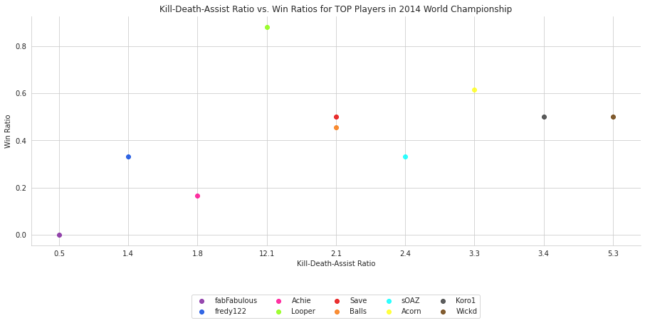

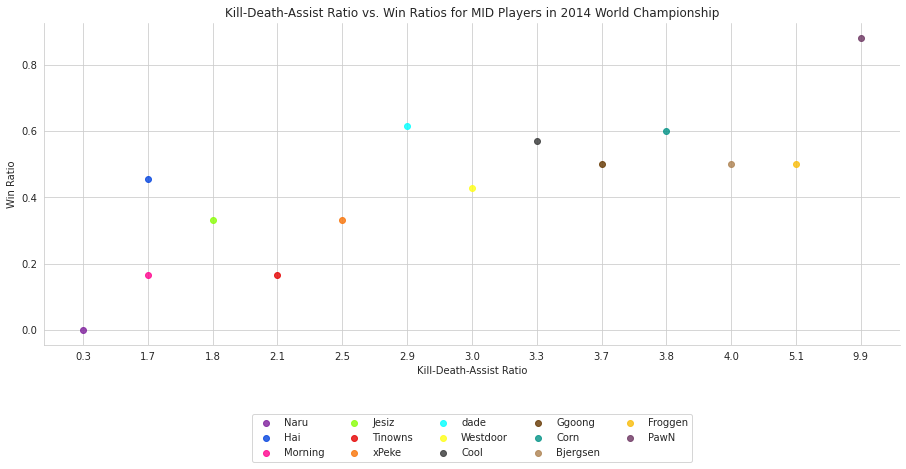

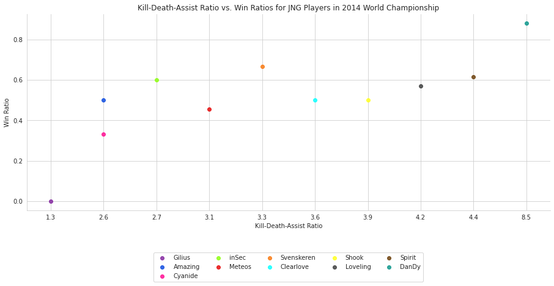

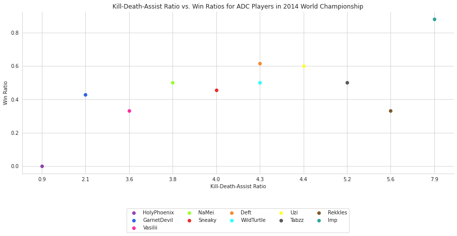

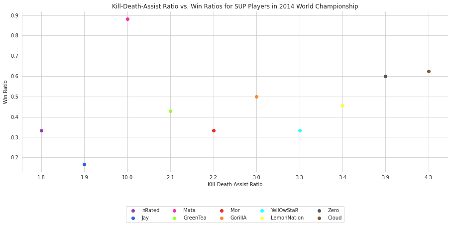

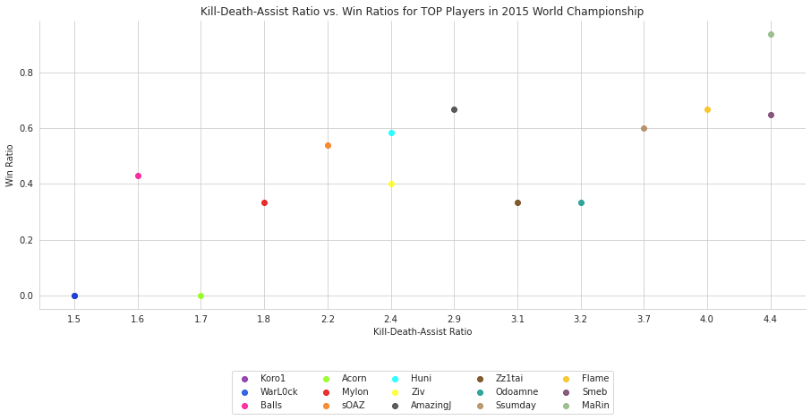

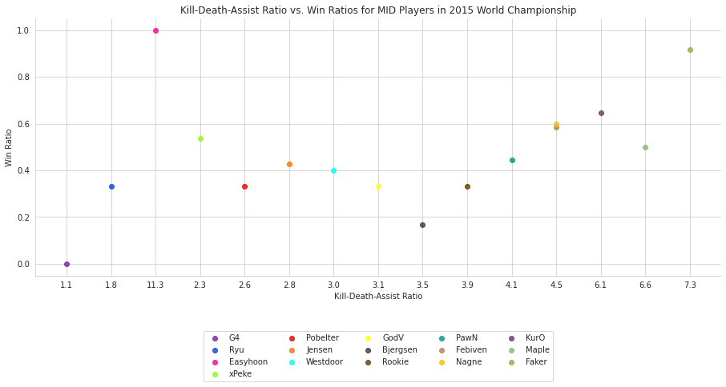

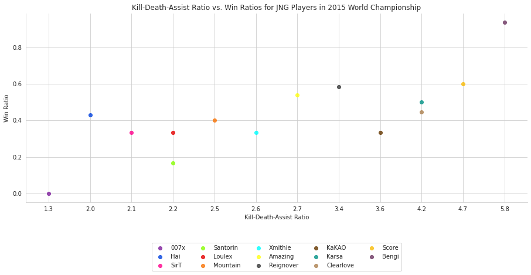

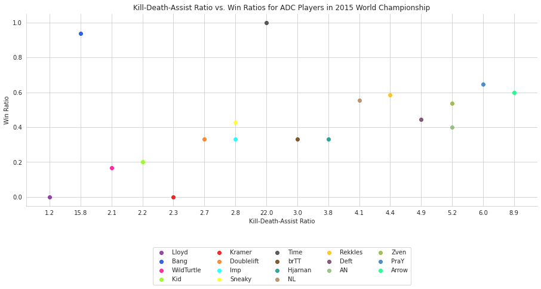

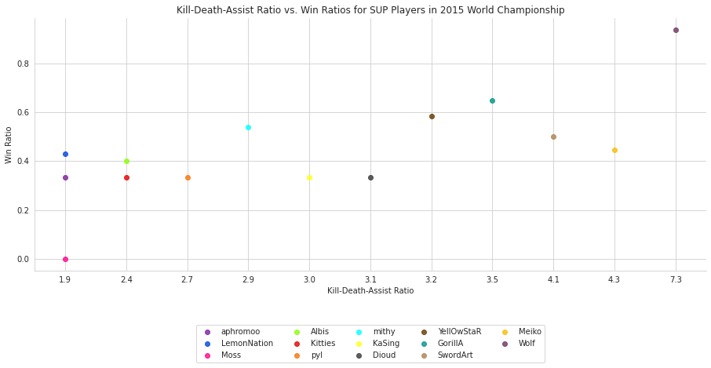

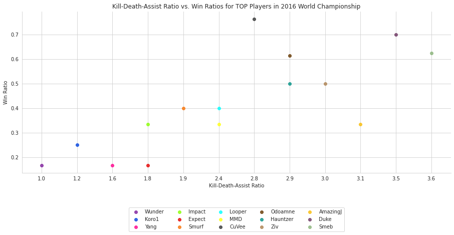

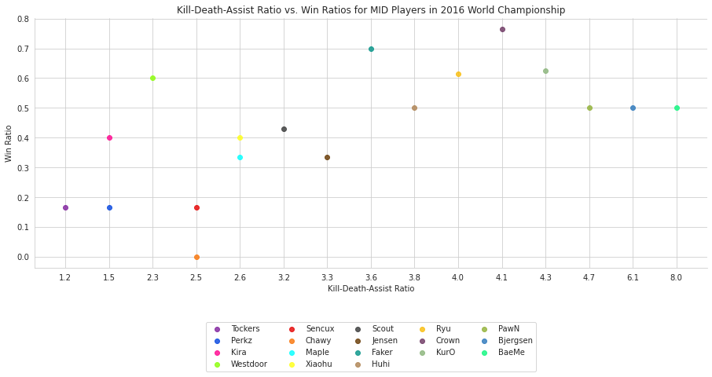

[23 more figures not shown]

```python
# Calculating win ratio for each positional dataframe for years 2014-2020
frames = [top2014,mid2014,jng2014,adc2014,sup2014,
          top2015,mid2015,jng2015,adc2015,sup2015,
          top2016,mid2016,jng2016,adc2016,sup2016,
          top2017,mid2017,jng2017,adc2017,sup2017,
          top2018,mid2018,jng2018,adc2018,sup2018,
          top2019,mid2019,jng2019,adc2019,sup2019,
          top2020,mid2020,jng2020,adc2020,sup2020]

# Iterate through list of dataframes and calculate a new win ratio column for each
for table in frames:
    table['winratio'] = pd.to_numeric(table['wins'])/pd.to_numeric(table['games'])

for table in frames:
    # Plot each positional dataframe for years 2014-2020
    table = table.sort_values(by='kda', ascending=True)
    sns.set_style('whitegrid')
    sns.lmplot(x='kda', y='winratio', data=table, fit_reg=False, palette=customPalette,
           hue='gamertag', height=5, aspect=2.5, legend=False)
    plt.legend(loc=9, bbox_to_anchor=(0.5, -0.2), ncol=5)
    plt.title('Kill-Death-Assist Ratio vs. Win Ratios for ' + table.iat[0,3] + ' Players in '
              +str(table.iat[0,0]) + ' World Championship')
    plt.xlabel('Kill-Death-Assist Ratio')
    plt.ylabel('Win Ratio')
    plt.show()
```

For all positional graphs throughout the years 2014-2020, it seems as if there is a positive relationship between getting more kills/assists than deaths and winning more often comparatively. While there are some datapoints throughout the graphs that show a relatively high win ratio compared to the player's low kill-death-assist ratio, which could lead us to surmise the possibility of particular in-game strategy which favors a passive playstyle and other external factors that may have affected the player's win ratio, a majority of the data points seem to fall within a linear growth model.

As for 2020 the statistics show that the best player in each respective role when factoring in Kill-Death-Assist Ratio and Win Ratio was Nuguri in the TOP position, ShowMaker in the MID position, Kongyue in the JNG position, Dee in the ADC position, and CoreJJ in the SUP position. This is quite a surprise as initially one would have assumed all positions would have been filled by players from the winning team for the World Championship of 2020.

## Predicting Win Ratio

In this last section, we will focus on trying to build a model that can accurately predict the win percentage of a player based off their kill-death-assist ratio. There are a variety of prediction models that we could use, but due to the many different catagories of positions and player statistics, we will be using a linear regression model.

## Linear Regression for Players

First in is bringing up the player statistics from the years of 2014-2020 throughout all positions. We will use the dfTotal dataframe created earlier on during our data preparation stage. We will drop everything except for the kill-death-assist column as well as add the win ratio column.

```python
# Calculating win ratio column for dfTotal dataframe
dfTotal['winratio'] = pd.to_numeric(dfTotal['wins'])/pd.to_numeric(dfTotal['games'])
```

```python
dfTotal = dfTotal.drop(['games','wins','losses','assists','kp','killshare','cs'
                        ,'csm','goldperc','dpm','fb','deathperc','wpm','wcpm','worldchamp'], axis = 1)
```

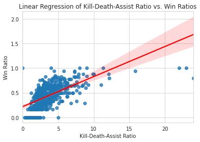

```python
# Perform Linear Regression on Kill-Death-Assist Ratio
X = dfTotal.iloc[:,4].values.reshape(-1,1)
Y = dfTotal.iloc[:,5].values.reshape(-1,1)
reg = LinearRegression()
reg.fit(X,Y)
Ypred = reg.predict(X)

X = X.astype('float64')

#Visualize Results
sns.regplot(x=X,y=Y,line_kws={'color': 'red'})
plt.title('Linear Regression of Kill-Death-Assist Ratio vs. Win Ratios')
plt.xlabel('Kill-Death-Assist Ratio')
plt.ylabel('Win Ratio')
plt.show()
```

With these results we can clearly see that our hypothesis of a linear growth model was correct, as there is in fact a linear growth in regards to win ratio and kill-death-assist ratios, leading us to the conclusion that a majority of professional players that have attended the League of Legends World Championship have above a 1.0 Kill-Death-Assist Ratio and that the chances of winning do in fact rise based off increasing kill-death-assist statistics.

This falls in line with standard recruiting tactics as many franchises and fantatsy drafts often begin scouting for talent by anaylzing the player's previous performance history statistics and kill-death-assist ratio from previous years. What is interesting to note is that there are some outliers in the kill-death-assist ratios that lead to some intresting conclusions, as having more than a 15.0 kill-death-assist ratio does not seem to increase winning percentages. This leads to speculation on other potential factors and statstics that have a weighted impact on win ratios that kill-death-assist ratios do not reveal. This however, will be outside the scope of our data analysis.

## Standardization of Win Ratios

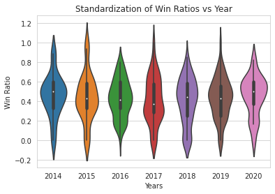

```python
sns.violinplot(x=dfTotal['year'], y=dfTotal['winratio'])
plt.title('Standardization of Win Ratios vs Year')
plt.xlabel('Years')
plt.ylabel('Win Ratio')
plt.show()
```

Great! The results fall within expectations of a normal distribution as they are unimodal violin graphs without too much skew to either and the mean of the plot (the white dot) lies approximately in the center of the distribution. While the win ratios of players seem to have dipped and risen again to around 0.5 one can speculate that the win ratio mean was at its lowest in 2017 due to the strong competitition that each team faced that year.

## Conclusion and Further Exploration

While I initally set out to find out what made a League of Legend professional "good" and who were statistically the best players, we ended up reaching our goal and learned a lot more about the factors and how closely tied the correlation between a player's win ratio and their Kill-Death-Assist ratio is. We also ended up learning a lot about the game thanks to the exploratory data analysis we went through while covering a large portion of the data science pipeline taught to us throughout our data science course, CMSC320.

In regards to further exploration, while we did not cover it within the scope of our data exploration, further research could be done in regards to the other player statistics that impacted a player's win ratio and quantifying them as a percentage to be able the weigh the impact that it has over the player's overall performance. Accessing a larger database that also includes regional tournaments could also open insights to player performance between teams and open up the possibility of using machine learning methods to pick up on player performance patterns between regions.

While League of Legends can be very complex, hopefully this tutorial provided some valuable insight for both inexperienced and experienced players. Even if this tutorial did not manage to pique your interest in the game, a lot of what we did could certainly be applied to other datasets since data science is all about tidying datasets, preparing them for further analysis, and plotting/explaining any relevant visualizations or models. Thank you for taking the time to read through this tutorial in its entirety and I hope to see you soon on Summoner's Rift!

[figure not shown]